# Week 4: Clustering and classification

Emma Haapa

# Week 4: Clustering and classification

### A look into the data set : The Boston data

The Boston dataset, more formally called “Housing Values in Suburbs of Boston”, is a dataset that can be found already installed within the MASS-package in R. The data and its variables can be explored from the tables below, produced by the str() and summary() functions of R. The dimensions of the Boston data are 506 rows and 14 columns, i. e. 506 observations and 14 variables, the type of which is either numeric or integer. In other words there are no character or factor type variables in this dataset. The names of the variables can be seen below, produced with the colnames()-function.

The data has variables measuring different aspects of housing and living in the city of Boston, including variables such as “rad” described as the index of accessibility to radial highways and “crim” that is the per capita crime rate by town. Of these the latter will be explored further in this week’s exercise.

More information regarding the Boston data can be found in this [link](https://stat.ethz.ch/R-manual/R-devel/library/MASS/html/Boston.html).

```
##  [1] "crim"    "zn"      "indus"   "chas"    "nox"     "rm"      "age"
##  [8] "dis"     "rad"     "tax"     "ptratio" "black"   "lstat"   "medv"
```

```
## [1] 506  14
```

```
## 'data.frame':    506 obs. of  14 variables:
##  $ crim   : num  0.00632 0.02731 0.02729 0.03237 0.06905 ...
##  $ zn     : num  18 0 0 0 0 0 12.5 12.5 12.5 12.5 ...
##  $ indus  : num  2.31 7.07 7.07 2.18 2.18 2.18 7.87 7.87 7.87 7.87 ...
##  $ chas   : int  0 0 0 0 0 0 0 0 0 0 ...
##  $ nox    : num  0.538 0.469 0.469 0.458 0.458 0.458 0.524 0.524 0.524 0.524 ...
##  $ rm     : num  6.58 6.42 7.18 7 7.15 ...
##  $ age    : num  65.2 78.9 61.1 45.8 54.2 58.7 66.6 96.1 100 85.9 ...
##  $ dis    : num  4.09 4.97 4.97 6.06 6.06 ...
##  $ rad    : int  1 2 2 3 3 3 5 5 5 5 ...
##  $ tax    : num  296 242 242 222 222 222 311 311 311 311 ...
##  $ ptratio: num  15.3 17.8 17.8 18.7 18.7 18.7 15.2 15.2 15.2 15.2 ...
##  $ black  : num  397 397 393 395 397 ...
##  $ lstat  : num  4.98 9.14 4.03 2.94 5.33 ...
##  $ medv   : num  24 21.6 34.7 33.4 36.2 28.7 22.9 27.1 16.5 18.9 ...
```

```
##       crim                zn             indus            chas
##  Min.   : 0.00632   Min.   :  0.00   Min.   : 0.46   Min.   :0.00000
##  1st Qu.: 0.08204   1st Qu.:  0.00   1st Qu.: 5.19   1st Qu.:0.00000
##  Median : 0.25651   Median :  0.00   Median : 9.69   Median :0.00000
##  Mean   : 3.61352   Mean   : 11.36   Mean   :11.14   Mean   :0.06917
##  3rd Qu.: 3.67708   3rd Qu.: 12.50   3rd Qu.:18.10   3rd Qu.:0.00000
##  Max.   :88.97620   Max.   :100.00   Max.   :27.74   Max.   :1.00000
##       nox               rm             age              dis
##  Min.   :0.3850   Min.   :3.561   Min.   :  2.90   Min.   : 1.130
##  1st Qu.:0.4490   1st Qu.:5.886   1st Qu.: 45.02   1st Qu.: 2.100
##  Median :0.5380   Median :6.208   Median : 77.50   Median : 3.207
##  Mean   :0.5547   Mean   :6.285   Mean   : 68.57   Mean   : 3.795
##  3rd Qu.:0.6240   3rd Qu.:6.623   3rd Qu.: 94.08   3rd Qu.: 5.188
##  Max.   :0.8710   Max.   :8.780   Max.   :100.00   Max.   :12.127
##       rad              tax           ptratio          black
##  Min.   : 1.000   Min.   :187.0   Min.   :12.60   Min.   :  0.32
##  1st Qu.: 4.000   1st Qu.:279.0   1st Qu.:17.40   1st Qu.:375.38
##  Median : 5.000   Median :330.0   Median :19.05   Median :391.44
##  Mean   : 9.549   Mean   :408.2   Mean   :18.46   Mean   :356.67
##  3rd Qu.:24.000   3rd Qu.:666.0   3rd Qu.:20.20   3rd Qu.:396.23
##  Max.   :24.000   Max.   :711.0   Max.   :22.00   Max.   :396.90
##      lstat            medv
##  Min.   : 1.73   Min.   : 5.00
##  1st Qu.: 6.95   1st Qu.:17.02
##  Median :11.36   Median :21.20
##  Mean   :12.65   Mean   :22.53
##  3rd Qu.:16.95   3rd Qu.:25.00
##  Max.   :37.97   Max.   :50.00
```

First, I wanted to see how the crime rate is affected by different variables. To do that, I created boxplots of some of the variables in relation to the crime rate -variable “crim”. I am not sure how useful these explorations are, however I decided to engage in them as I thought it would at least be good practice, if not anything else. Consequently, I created a new variable “high_crim” by mutating the Boston data and setting high_crim to be true when the crim-variable gets values from (roughly) above the mean (3.6…). The variables I chose are those that in my opinion might have some kind of connection or relationship with the crime rate, the variables being the following:

“lstat” = lower status of the population (percent) “rad” = index of accessibility to radial highways.

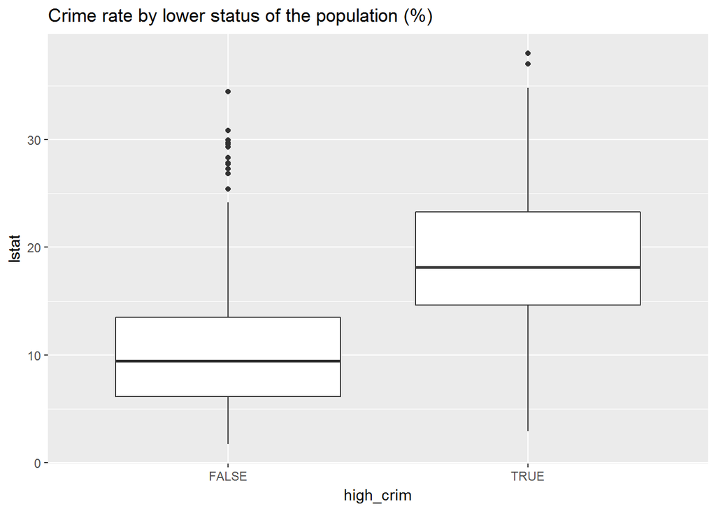

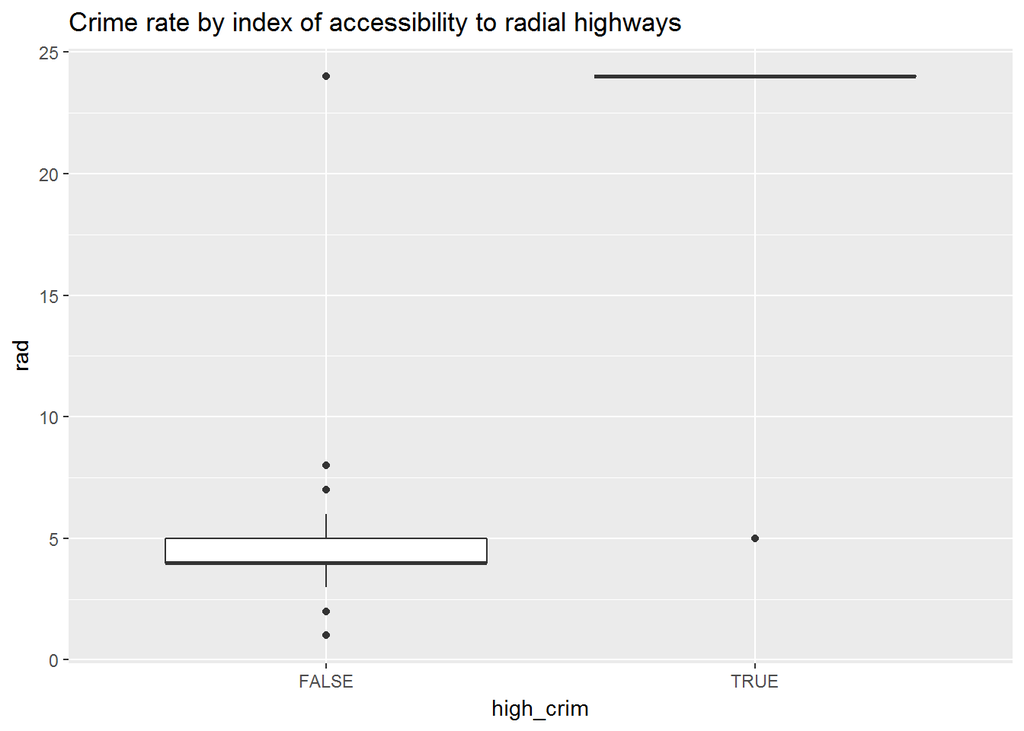

Judging from the first box plot it seems that when the percent of population classified as lower is higher, the high_crime-variable gets the value TRUE. This essentially means that when there are more “lower class” -people in the neighbourhood or town, also the crime rate is elevated. This confirms tosome extent my initial hypothesis of these variables having some kind of connection, and also goes along with the intuition that low-class neighbourhoods have a higher crime rate than those inhabitated by people of the wealthier upper or mid-class. The second box plot shows that higher crime rate is in connection to the access to radial highways, as the high_crime variable gets the value TRUE for high values of the access to highways -variable. One could think that areas in the midst of or in the crossroads of big highways would have more traffic, more people and more gangs etc., i. e. more criminal activity would take place in that kind of environment.

To look at the correlation and relationships between all the variables in general, I created plots and correlation matrices with pairs()- and cor()-functions. Below the correlation matrix is also visualized with the corrplot()-function.

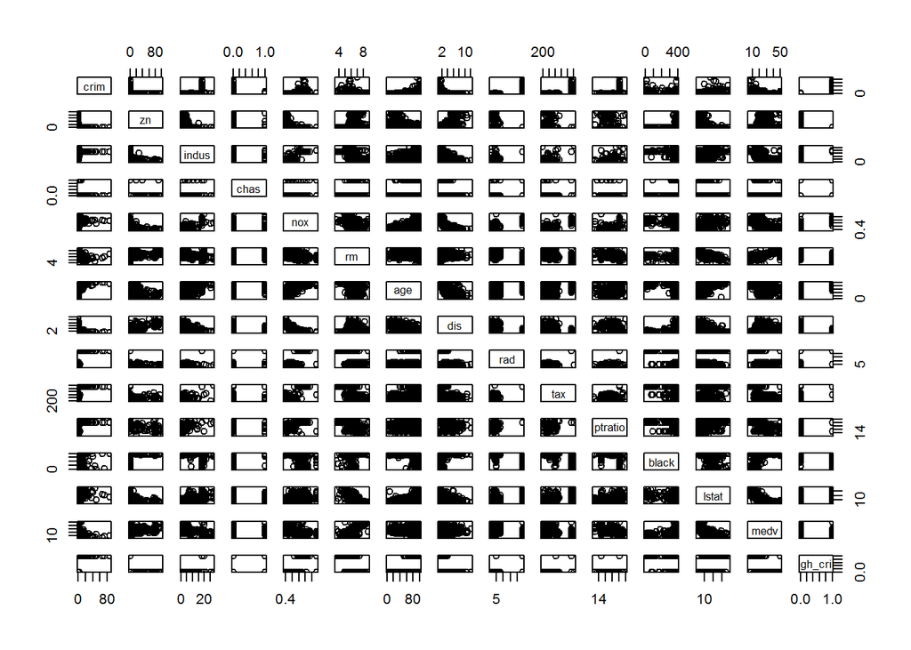

```
##            crim    zn indus  chas   nox    rm   age   dis   rad   tax
## crim       1.00 -0.20  0.41 -0.06  0.42 -0.22  0.35 -0.38  0.63  0.58
## zn        -0.20  1.00 -0.53 -0.04 -0.52  0.31 -0.57  0.66 -0.31 -0.31
## indus      0.41 -0.53  1.00  0.06  0.76 -0.39  0.64 -0.71  0.60  0.72
## chas      -0.06 -0.04  0.06  1.00  0.09  0.09  0.09 -0.10 -0.01 -0.04
## nox        0.42 -0.52  0.76  0.09  1.00 -0.30  0.73 -0.77  0.61  0.67
## rm        -0.22  0.31 -0.39  0.09 -0.30  1.00 -0.24  0.21 -0.21 -0.29
## age        0.35 -0.57  0.64  0.09  0.73 -0.24  1.00 -0.75  0.46  0.51
## dis       -0.38  0.66 -0.71 -0.10 -0.77  0.21 -0.75  1.00 -0.49 -0.53
## rad        0.63 -0.31  0.60 -0.01  0.61 -0.21  0.46 -0.49  1.00  0.91
## tax        0.58 -0.31  0.72 -0.04  0.67 -0.29  0.51 -0.53  0.91  1.00
## ptratio    0.29 -0.39  0.38 -0.12  0.19 -0.36  0.26 -0.23  0.46  0.46
## black     -0.39  0.18 -0.36  0.05 -0.38  0.13 -0.27  0.29 -0.44 -0.44
## lstat      0.46 -0.41  0.60 -0.05  0.59 -0.61  0.60 -0.50  0.49  0.54
## medv      -0.39  0.36 -0.48  0.18 -0.43  0.70 -0.38  0.25 -0.38 -0.47
## high_crim  0.64 -0.28  0.59 -0.03  0.61 -0.24  0.47 -0.49  0.96  0.88
##           ptratio black lstat  medv high_crim
## crim         0.29 -0.39  0.46 -0.39      0.64
## zn          -0.39  0.18 -0.41  0.36     -0.28
## indus        0.38 -0.36  0.60 -0.48      0.59
## chas        -0.12  0.05 -0.05  0.18     -0.03
## nox          0.19 -0.38  0.59 -0.43      0.61
## rm          -0.36  0.13 -0.61  0.70     -0.24
## age          0.26 -0.27  0.60 -0.38      0.47
## dis         -0.23  0.29 -0.50  0.25     -0.49
## rad          0.46 -0.44  0.49 -0.38      0.96
## tax          0.46 -0.44  0.54 -0.47      0.88
## ptratio      1.00 -0.18  0.37 -0.51      0.46
## black       -0.18  1.00 -0.37  0.33     -0.45
## lstat        0.37 -0.37  1.00 -0.74      0.51
## medv        -0.51  0.33 -0.74  1.00     -0.40
## high_crim    0.46 -0.45  0.51 -0.40      1.00
```

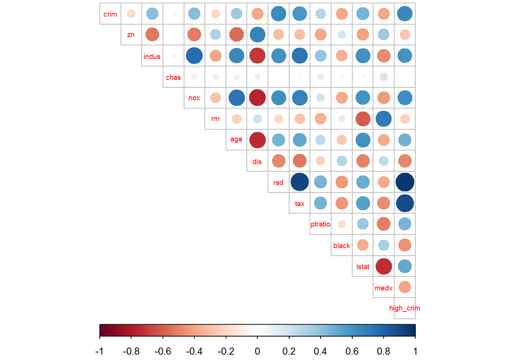

The picture produced with the pairs()-function is a bit hard to interpret, ut it provides a glimpse onto the relationships between all the variables in the dataset. For a more thorough look at the relationships one could consider the correlation matrix and its very useful visualization. From the aforementioned two we can see that the variable rad of which I created the boxplot with high_crime earlier, has a quite strong positive correlation with crime, the value of it being 0.63. It is depicted in the vizualization with a rather large and opaque, blue dot. So in other words, when the rad-variable increases, so does the crime rate. We can also notice that the lstat-variable has also a somewhat significant (0.46) positive correlation with the crime rate variable, which is shown as a slightly lighter blue dot in the visualization. So high values for lstat mean high values for crim.

Also the tax and nox variables (full-value property-tax rate per $10,000 and nitrogen oxides concentration (parts per 10 million)) have a positive correlation with crime rate, 0.58 and 0.42 respectively. Furthermore, tax rate correlates positively with rad (access to highways) so the more accessible the city/are the more crime it has (over-simplifiedly put). The med variable or the median value of owner-occupied homes in $1000s on the other hand correlated negatively with lstat, or the lower status of the population, the value being -0.74. Intuitively, this makes sense since lower class population more probably doesn’t own high value homes if it owns homes at all. The negative correlation is denoted as red colour in the visualization, and accordingly, the dot between the medv- and lstat-variables is rather big and red.

According to the instructions, I scaled the Boston dataset and changed the object’s class to be data frame. The scaling needs to be done in order to perform Linear Discriminant Analysis on the data, as the assumptions of the analysis are that the variables are normally distributed and have the same variance. In order to ger this result, the scale()-function scales the variables by distracting the mean and dividing the result by standard deviation, resulting in the means of the variables to be exactly equal to zero, as can be seen from the summary. In that way the variables are centered and standardized, i. e. more easily comparable to each other and more calculations can be done based on the relations between the variables as they’re measured on the same range.

```r
# center and standardize variables
boston_scaled <- scale(Boston)

# summaries of the scaled variables
summary(boston_scaled)
```

```
##       crim                 zn               indus
##  Min.   :-0.419367   Min.   :-0.48724   Min.   :-1.5563
##  1st Qu.:-0.410563   1st Qu.:-0.48724   1st Qu.:-0.8668
##  Median :-0.390280   Median :-0.48724   Median :-0.2109
##  Mean   : 0.000000   Mean   : 0.00000   Mean   : 0.0000
##  3rd Qu.: 0.007389   3rd Qu.: 0.04872   3rd Qu.: 1.0150
##  Max.   : 9.924110   Max.   : 3.80047   Max.   : 2.4202
##       chas              nox                rm               age
##  Min.   :-0.2723   Min.   :-1.4644   Min.   :-3.8764   Min.   :-2.3331
##  1st Qu.:-0.2723   1st Qu.:-0.9121   1st Qu.:-0.5681   1st Qu.:-0.8366
##  Median :-0.2723   Median :-0.1441   Median :-0.1084   Median : 0.3171
##  Mean   : 0.0000   Mean   : 0.0000   Mean   : 0.0000   Mean   : 0.0000
##  3rd Qu.:-0.2723   3rd Qu.: 0.5981   3rd Qu.: 0.4823   3rd Qu.: 0.9059
##  Max.   : 3.6648   Max.   : 2.7296   Max.   : 3.5515   Max.   : 1.1164
##       dis               rad               tax             ptratio
##  Min.   :-1.2658   Min.   :-0.9819   Min.   :-1.3127   Min.   :-2.7047
##  1st Qu.:-0.8049   1st Qu.:-0.6373   1st Qu.:-0.7668   1st Qu.:-0.4876
##  Median :-0.2790   Median :-0.5225   Median :-0.4642   Median : 0.2746
##  Mean   : 0.0000   Mean   : 0.0000   Mean   : 0.0000   Mean   : 0.0000
##  3rd Qu.: 0.6617   3rd Qu.: 1.6596   3rd Qu.: 1.5294   3rd Qu.: 0.8058
##  Max.   : 3.9566   Max.   : 1.6596   Max.   : 1.7964   Max.   : 1.6372
##      black             lstat              medv           high_crim
##  Min.   :-3.9033   Min.   :-1.5296   Min.   :-1.9063   Min.   :-0.5813
##  1st Qu.: 0.2049   1st Qu.:-0.7986   1st Qu.:-0.5989   1st Qu.:-0.5813
##  Median : 0.3808   Median :-0.1811   Median :-0.1449   Median :-0.5813
##  Mean   : 0.0000   Mean   : 0.0000   Mean   : 0.0000   Mean   : 0.0000
##  3rd Qu.: 0.4332   3rd Qu.: 0.6024   3rd Qu.: 0.2683   3rd Qu.: 1.7168
##  Max.   : 0.4406   Max.   : 3.5453   Max.   : 2.9865   Max.   : 1.7168
```

```r
# change the object to data frame

boston_scaled <- as.data.frame(boston_scaled)
```

```
## crime
##   1   2   3   4
## 127 126 126 127
```

### The Linear Discriminant Analysis (LDA)

[output not shown]

[output not shown]

[output not shown]

[output not shown]

[output not shown]

[output not shown]

[output not shown]

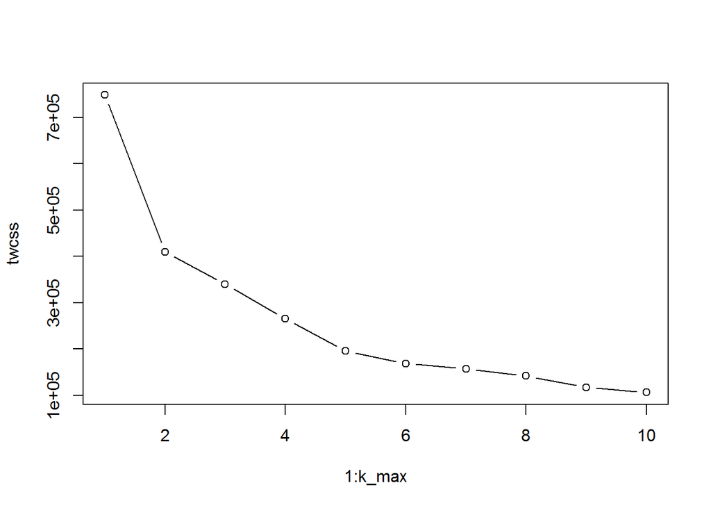

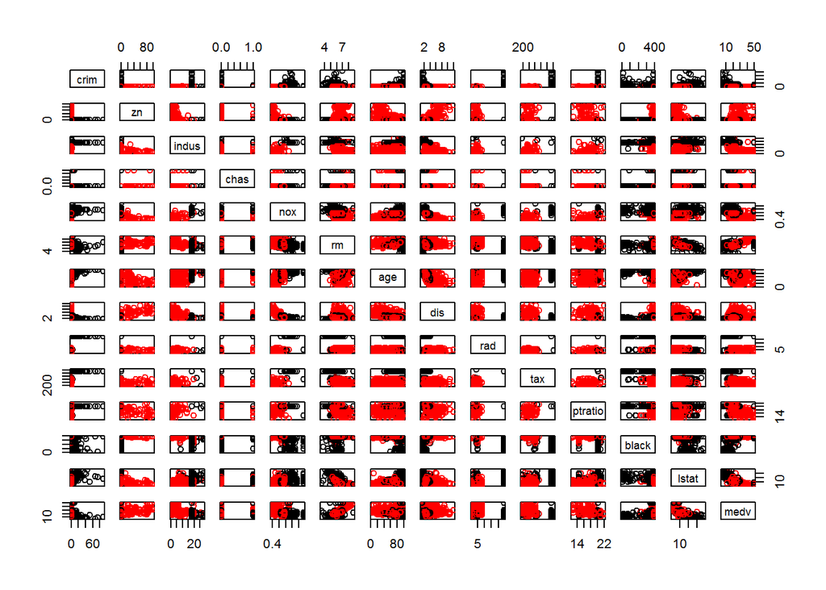

```
## Call:
## lda(km$cluster ~ ., data = Boston)
##
## Prior probabilities of groups:
##         1         2         3
## 0.1699605 0.2964427 0.5335968
##
## Group means:
##        crim          zn     indus       chas       nox       rm      age
## 1 14.410307  1.04651163 18.412791 0.18604651 0.6955465 5.889453 92.21977
## 2  3.594889  0.08333333 16.201800 0.02666667 0.6192800 6.036413 88.09867
## 3  0.184901 20.91666667  6.005333 0.05555556 0.4739507 6.548407 50.19704
##        dis       rad      tax  ptratio    black     lstat     medv
## 1 1.810314 19.941860 616.1279 19.23721 231.9315 20.426628 16.44186
## 2 2.561713 12.773333 496.2600 19.56667 369.0913 16.157333 18.00800
## 3 5.112399  4.448148 293.1185 17.58926 389.5083  8.230222 26.98667
##
## Coefficients of linear discriminants:
##                  LD1           LD2
## crim    -0.030828366  0.0869664519
## zn      -0.015314358 -0.0059126472
## indus   -0.069679715 -0.0883096847
## chas    -1.339918668  1.6001162814
## nox     -5.141704866  3.0477474546
## rm       0.391059024 -0.3225584287
## age     -0.009923483 -0.0211950792
## dis      0.090002927  0.1210279332
## rad      0.046659074 -0.0163781763
## tax     -0.005000880 -0.0001812208
## ptratio -0.139896301 -0.0984855812
## black    0.006186019 -0.0092407719
## lstat   -0.072113484  0.0424045403
## medv    -0.037617137  0.0666347548
##
## Proportion of trace:
##    LD1    LD2
## 0.8828 0.1172
```

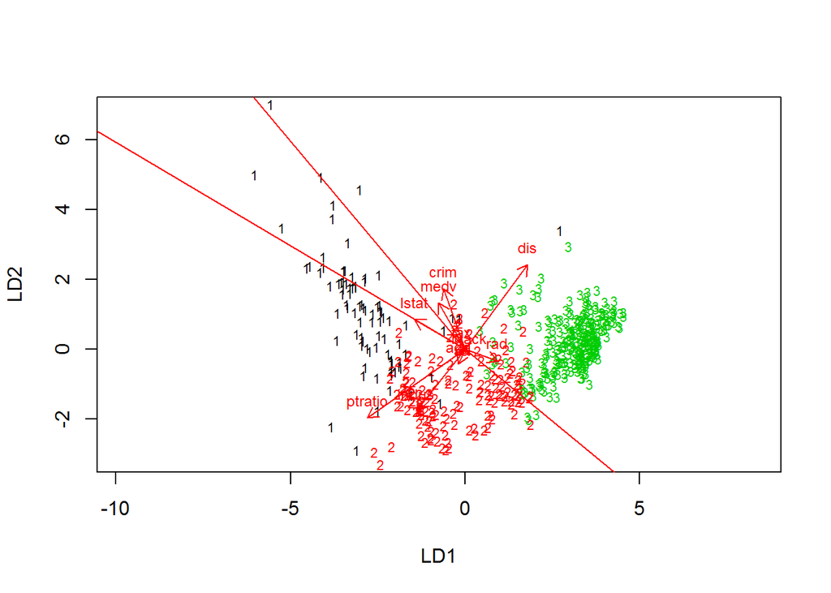